# Pauses in a fast paced life: Intermittent hovering in hummingbirds

Kristiina Hurme, Ana Melisa Fernandes, Diego Andrés Benitez Duarte, Marialejandra Castro-Farías, Gary Stiles, Ashley Smiley, Christopher J. Clark, Alejandro Rico-Guevara

## 1. Introduction and Dependencies

This document contains the reproducible workflow for the analysis of evolutionary correlations between flight behavior and morphology in hummingbirds.

```r
# INSTALLATION AND LOADING
if (!require("BiocManager", quietly = TRUE)) install.packages("BiocManager")
if (!require("ggtree", quietly = TRUE)) BiocManager::install("ggtree")
if (!require("pacman")) install.packages("pacman")
if (!require("here")) install.packages("here")

pacman::p_load(
    phytools, ggtree, caper, tidyverse, RColorBrewer, readxl, janitor, nlme,
    ape, phylolm, cowplot, caret, kableExtra, ggplotify, here
)
```

## 2. Auxiliary Functions

Custom functions defined for coefficient extraction, forest plot generation, and metric calculation.

```r
source(here::here("R", "functions.R"))
```

## 3. Data Loading and Curation

Data and phylogeny are loaded using relative paths for reproducibility.

```r
data_path <- here("Data", "Trochilidae_MorphoBehavior_Data.xlsx")
tree_path <- here("Data", "arbol.nwk")

data_raw <- read_excel(data_path, sheet = "Pausas_Tipo")
data_raw <- data_raw[data_raw$Species != "Sternoclyta cyanopectus", ]
tree_raw <- read.tree(tree_path)

# Data Cleaning
data_raw[, c(FALSE, sapply(data_raw[,-1], is.character))] <-
    lapply(data_raw[, c(FALSE, sapply(data_raw[,-1], is.character))], factor)
data_clean <- data_raw %>% clean_names()

data_clean$species <- gsub(" ", "_", data_clean$species)
tree_raw$tip.label <- gsub(" ", "_", tree_raw$tip.label)
```

### 3.1 Phylogenetic Tree Modification

Manual addition of missing species based on literature/taxonomy.

**Justification for tree manipulation** The species absent from the original phylogeny was grafted onto the clade to which it belongs (e.g., node 176). A short branch length was applied to treat the divergence as a recent speciation event or a conserved change, thus ensuring the inclusion of the species’ morphological data in the analysis without overestimating its evolutionary uniqueness and without significantly affecting the phylogeny’s topology. Values were sought that would not significantly alter the outcome of a PGLS or a phylogenetic signal (Lambda), aiming for small values compared to the total height of the tree.

```r
tree_mod <- bind.tip(tree_raw, "Aglaeactis_aliciae", edge.length = 0.2, where = 176)
tree_mod <- bind.tip(tree_mod, "Lamprolaima_rhami", edge.length = 3.2, where = 107)
tree_mod <- bind.tip(tree_mod, "Sternoclyta_cyanopectus", edge.length = 6.0, where = 108)
tree_mod <- bind.tip(tree_mod, "Oxypogon_lindenii", edge.length = 1.6, where = 230)
tree_mod <- bind.tip(tree_mod, "Urochroa_leucura", edge.length = 0.8, where = 154)

# Taxonomy Harmonization
name_replacements <- c(
    "Chlorostilbon_notatus" = "Chlorestes_notata",
    "Damophila_julie" = "Chlorestes_julie",
    "Goethalsia_bella" = "Goldmania_bella",
    "Lophornis_pavoninus" = "Lophornis_adorabilis",
    "Cyanophaia_bicolor" = "Riccordia_bicolor",
    "Amazilia_beryllina" = "Saucerottia_beryllina",
    "Amazilia_castaneiventris" = "Saucerottia_castaneiventris",
    "Amazilia_cyanura" = "Saucerottia_cyanura",
    "Heliodoxa_cyanopectus" = "Sternoclyta_cyanopectus",
    "Campylopterus_villaviscencio" = "Campylopterus_villaviscensio"
)

tree_mod$tip.label <- ifelse(tree_mod$tip.label %in% names(name_replacements),
                             name_replacements[tree_mod$tip.label], tree_mod$tip.label)

if (any(tree_mod$edge.length <= 0)) tree_mod$edge.length[tree_mod$edge.length <= 0] <- 1e-6
if (!is.ultrametric(tree_mod)) tree_mod <- chronopl(tree_mod, lambda = 1)
tree_mod$tip.label <- gsub(" ", "_", tree_mod$tip.label)

# Final Match
common_spp <- intersect(data_clean$species, tree_mod$tip.label)
tree_bin <- keep.tip(tree_mod, common_spp)
data_bin <- data_clean %>% filter(species %in% common_spp) %>% arrange(match(species, tree_bin$tip.label))
data_bin <- as.data.frame(data_bin)
rownames(data_bin) <- data_bin$species

data_bin <- data_bin %>%
    filter(hovering_pauses %in% c("YES", "NO")) %>%
    filter(color %in% c("YES", "NO")) %>%
    filter(!is.na(wing_length)) %>%
    mutate(winglength_vs_mass = winglength_rel_mass2)

final_spp <- intersect(data_bin$species, tree_bin$tip.label)
tree_bin <- keep.tip(tree_bin, final_spp)
data_bin <- data_bin[match(tree_bin$tip.label, data_bin$species), ]

if (any(duplicated(tree_bin$tip.label))) {
    dup_idx <- which(duplicated(tree_bin$tip.label))
    tree_bin <- drop.tip(tree_bin, dup_idx)
    data_bin <- data_bin[match(tree_bin$tip.label, data_bin$species), ]
}

data_bin$hovering_pauses_01 <- ifelse(data_bin$hovering_pauses == "YES", 1, 0)
# Define color palettes matching the analysis aesthetics
levels_bin <- c("NO", "YES")
cols_hover_plt <- c("NO" = "#56B4E9", "YES" = "#CC79A7")
cols_color_plt <- c("NO" = "#9BB0C1", "YES" = "#B2FF59")
cols_trans_plt <- c("NO" = "#1B9E77", "YES" = "#D95F02")
```

### 3.2 Outlier Detection and The Patagona gigas Effect

Before proceeding with evolutionary modeling, we evaluate the presence of outliers that could disproportionately leverage the phylogenetic regressions.

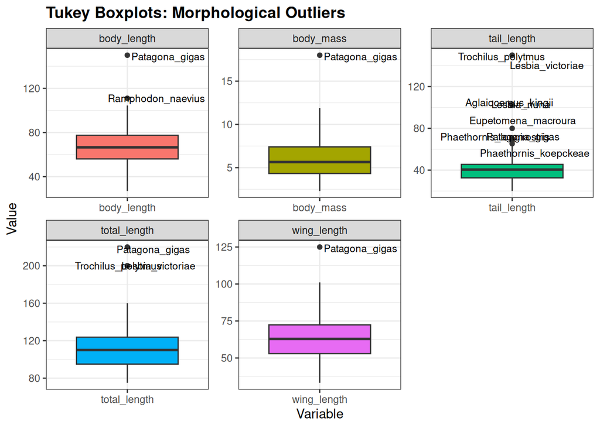

```r
library(ggrepel)

is_outlier <- function(x) {
  return(x < quantile(x, 0.25, na.rm=T) - 1.5 * IQR(x, na.rm=T) | x > quantile(x, 0.75, na.rm=T) + 1.5 * IQR(x, na.rm=T))
}

# Generate Tukey boxplots to identify structural outliers
p_box <- data_bin %>%
    dplyr::select(species, wing_length, body_mass, tail_length,
                  total_length, body_length) %>%
    gather(key = "Variable", value = "Value", -species) %>%
    drop_na(Value) %>%
    group_by(Variable) %>%
    mutate(Outlier = ifelse(is_outlier(Value), species, NA_character_)) %>%
    ggplot(aes(Variable, Value, fill = Variable)) +
    geom_boxplot(outlier.shape = 19) +
    facet_wrap(~Variable, scales = "free") +
    geom_text_repel(aes(label = Outlier), na.rm = TRUE, hjust = -0.5, size=3) +
    theme_bw() +
    theme(legend.position = "none", plot.title = element_text(face="bold")) +
    labs(title = "Tukey Boxplots: Morphological Outliers")

# Visualizing the structural impact of Patagona gigas on regressions
# Categorize body mass for the Interaction (Wing * Mass)
data_bin$mass_class <- cut(data_bin$body_mass,
                           breaks = quantile(data_bin$body_mass, probs = c(0, 0.5, 1), na.rm=TRUE),
                           labels = c("Light", "Heavy"), include.lowest = TRUE)

# Plot WITH Patagona
p_with <- ggplot(data_bin, aes(x = wing_length,
                               y = hovering_pauses_01)) +
    geom_jitter(aes(color = mass_class), height = 0.05, width = 0,
                alpha = 0.6, size = 3) +
    geom_smooth(aes(group = mass_class, color = mass_class,
                    fill = mass_class),
                method = "glm",
                method.args = list(family = "binomial"), alpha = 0.2) +
    scale_color_manual(values = c("Light" = "#E69F00", "Heavy" = "#56B4E9")) +
    scale_fill_manual(values = c("Light" = "#E69F00", "Heavy" = "#56B4E9")) +
    labs(title = "Interaction: Wing * Mass (With Patagona, N=86)",
         x = "Wing Length (mm)",
         y = "Probability of Hovering Pauses",
         color = "Mass Category", fill = "Mass Category") +
    theme_minimal() + theme(legend.position = "bottom",
                            plot.title = element_text(face="bold", size=10))

# Plot WITHOUT Patagona
p_without <- data_bin %>% filter(species != "Patagona_gigas") %>%
    ggplot(aes(x = wing_length, y = hovering_pauses_01)) +
    geom_jitter(aes(color = mass_class), height = 0.05, width = 0,
                alpha = 0.6, size = 3) +
    geom_smooth(aes(group = mass_class, color = mass_class,
                    fill = mass_class),
                method = "glm",
                method.args = list(family = "binomial"), alpha = 0.2) +
    scale_color_manual(values = c("Light" = "#E69F00", "Heavy" = "#56B4E9")) +
    scale_fill_manual(values = c("Light" = "#E69F00", "Heavy" = "#56B4E9")) +
    labs(title = "Interaction: Wing * Mass (Without Patagona, N=85)",
         x = "Wing Length (mm)", y = "Probability of Hovering Pauses",
         color = "Mass Category", fill = "Mass Category") +
    theme_minimal() +
    theme(legend.position = "bottom",
          plot.title = element_text(face="bold", size=10))

# Display plots
print(p_box)
```

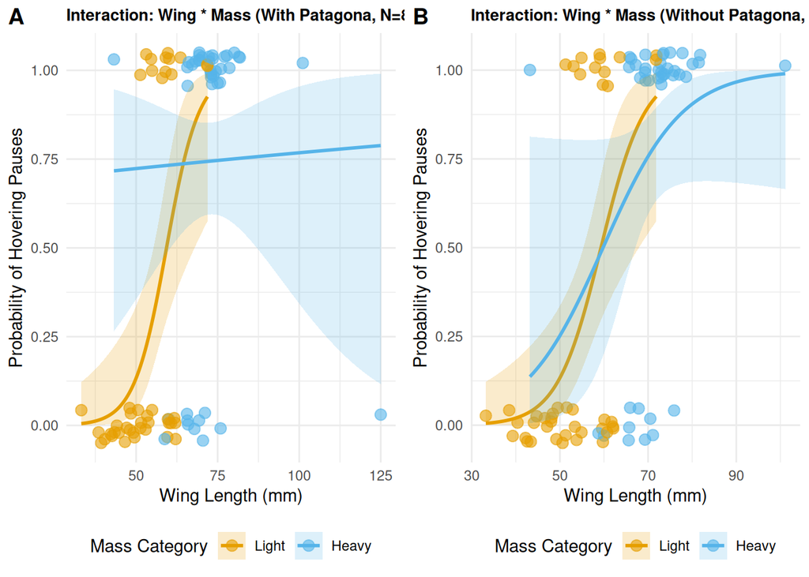

```r
plot_grid(p_with, p_without, ncol = 2, labels = c("A", "B"))
```

```r
# EXCLUDE PATAGONA GIGAS FOR ALL DOWNSTREAM EVOLUTIONARY ANALYSES
data_bin <- data_bin %>% filter(species != "Patagona_gigas")
tree_bin <- drop.tip(tree_bin, "Patagona_gigas")
```

## 4. Model Selection & Variable Importance

Multi-model inference evaluating the relative importance of distinct morphological variables using AICc. Based on the previous section, *Patagona gigas* has been excluded to ensure robust phylogenetic regressions.

### 4.1 Base Model Selection

```r
formulas <- list(
    "H0: Null Model (Random)"          = "hovering_pauses_01 ~ 1",
    "H1: Wing Length"                  = "hovering_pauses_01 ~ wing_length",
    "H2: Body Mass"                    = "hovering_pauses_01 ~ body_mass",
    "H3: Tail Length"                  = "hovering_pauses_01 ~ tail_length",
    "H4: Total Length"                 = "hovering_pauses_01 ~ total_length",
    "H5: Body Length"                  = "hovering_pauses_01 ~ body_length",
    "H6: Wing + Mass (Additive)"       = "hovering_pauses_01 ~ wing_length + body_mass",
    "H7: Wing * Mass (Interaction)"    = "hovering_pauses_01 ~ wing_length * body_mass"
)

if(length(unique(data_bin$microhabitat)) > 1) {
    formulas[["H8: Microhabitat"]] <- "hovering_pauses_01 ~ microhabitat"
}

model_results <- data.frame(Model_Name = character(),
                            Formula = character(),
                            AICc = numeric(),
                            Delta_AICc = numeric(),
                            Weight = numeric(),
                            P_Value_Main = numeric(),
                            stringsAsFactors = FALSE)

n <- nrow(data_bin)
for (name in names(formulas)) {
    f <- as.formula(formulas[[name]])
    try({
        mod <- phyloglm(f, data = data_bin, phy = tree_bin,
                        method = "logistic_MPLE")
        k <- length(coef(mod))
        aicc_val <- AIC(mod) + (2*k*(k+1)) / (n - k - 1)

        p_val <- NA
        if (name != "H0: Null Model (Random)") {
            cfs <- summary(mod)$coefficients
            idx <- nrow(cfs)
            # Extract p-value of the last term (useful for interactions or main effect)
            if(!is.na(idx)) p_val <- cfs[idx, 4]
        }
        model_results <- rbind(model_results,
                               data.frame(Model_Name = name,
                                          Formula = formulas[[name]],
                                          AICc = aicc_val,
                                          Delta_AICc = 0,
                                          Weight = 0,
                                          P_Value_Main = round(p_val, 5)))
    }, silent = TRUE)
}

if(nrow(model_results) > 0) {
    min_aicc <- min(model_results$AICc)
    model_results$Delta_AICc <- round(model_results$AICc - min_aicc, 2)
    rel_ll <- exp(-0.5 * model_results$Delta_AICc)
    model_results$Weight <- round(rel_ll / sum(rel_ll), 3)
    model_results <- model_results[order(model_results$Delta_AICc), ]

    model_results %>%
      select(Model_Name, Delta_AICc, Weight, P_Value_Main) %>%
      kbl(caption = "Model Selection Ranking (AICc)", align = "c") %>%
      kable_classic(full_width = F, html_font = "Cambria") %>%
      row_spec(0, bold = T, color = "white", background = "#2c3e50") %>%
      row_spec(1, bold = T, background = "#d1f2eb")
}
```

Model Selection Ranking (AICc)

|  | Model_Name | Delta_AICc | Weight | P_Value_Main |
| --- | --- | --- | --- | --- |
| 3 | H2: Body Mass | 0.00 | 0.322 | 0.02290 |
| 1 | H0: Null Model (Random) | 0.47 | 0.255 | NA |
| 2 | H1: Wing Length | 0.50 | 0.251 | 0.00003 |
| 7 | H6: Wing + Mass (Additive) | 3.07 | 0.069 | 0.44659 |
| 8 | H7: Wing * Mass (Interaction) | 3.18 | 0.066 | 0.21605 |
| 4 | H3: Tail Length | 5.24 | 0.023 | 0.99856 |
| 6 | H5: Body Length | 8.17 | 0.005 | 0.00159 |
| 9 | H8: Microhabitat | 8.62 | 0.004 | 0.11174 |
| 5 | H4: Total Length | 8.82 | 0.004 | 0.92676 |

## 5. Phylogenetic Signal & Modeling

### 5.1 Phylogenetic Signal (D Statistic)

```r
signals_bin <- list()
for (cat in levels_bin) {
    var_bin <- as.numeric(data_bin$hovering_pauses == cat)
    names(var_bin) <- data_bin$species
    data_temp <- data.frame(species = data_bin$species, state_bin = var_bin, stringsAsFactors = FALSE)
    comp_data <- comparative.data(tree_bin, data_temp, names.col = "species")
    d_res <- phylo.d(comp_data, binvar = state_bin, permut = 100)
    signals_bin[[cat]] <- d_res
}
print(signals_bin)
```

```
## $NO
##
## Calculation of D statistic for the phylogenetic structure of a binary variable
##
##   Data :  data_temp
##   Binary variable :  state_bin
##   Counts of states:  0 = 45
##                      1 = 40
##   Phylogeny :  tree_bin
##   Number of permutations :  100
##
## Estimated D :  -0.8953624
## Probability of E(D) resulting from no (random) phylogenetic structure :  0
## Probability of E(D) resulting from Brownian phylogenetic structure    :  1
##
##
## $YES
##
## Calculation of D statistic for the phylogenetic structure of a binary variable
##
##   Data :  data_temp
##   Binary variable :  state_bin
##   Counts of states:  0 = 40
##                      1 = 45
##   Phylogeny :  tree_bin
##   Number of permutations :  100
##
## Estimated D :  -1.064012
## Probability of E(D) resulting from no (random) phylogenetic structure :  0
## Probability of E(D) resulting from Brownian phylogenetic structure    :  1
```

### 4.2 PhyloGLM & Heatmap

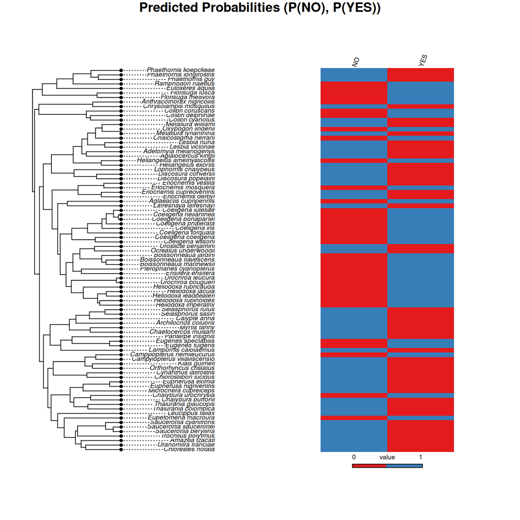

```r
model_hover_yes <- phyloglm(hovering_pauses_01 ~ wing_length,
                            data = data_bin, phy = tree_bin, method = "logistic_MPLE")

prob_yes <- model_hover_yes$fitted.values
prob_matrix <- cbind(NO = 1 - prob_yes, YES = prob_yes)
rownames(prob_matrix) <- data_bin$species

if (all(!is.na(prob_matrix))) {
    phylo.heatmap(tree_bin, prob_matrix, standardize = FALSE,
                  legend = TRUE, fsize = 0.6, colors = c("#E41A1C", "#377EB8"))
    title("Predicted Probabilities (P(NO), P(YES))")
}
```

## 6. Evolutionary Correlations (Pagel)

Testing correlated evolution between pauses and microhabitat/foraging strategy.

```r
# Correlation vs Microhabitat
data_pagel_hab <- data_bin %>%
    mutate(habitat_bin = case_when(
        microhabitat %in% c("Canopy", "Understory") ~ "Closed",
        microhabitat %in% c("Open", "Mixed")        ~ "Open",
        TRUE ~ NA_character_
    )) %>%
    filter(!is.na(habitat_bin), !is.na(hovering_pauses)) %>% droplevels()

sp_hab <- intersect(data_pagel_hab$species, tree_bin$tip.label)
tree_hab <- keep.tip(tree_bin, sp_hab)
data_pagel_hab <- data_pagel_hab[match(sp_hab, data_pagel_hab$species), ]

r1 <- setNames(factor(data_pagel_hab$hovering_pauses), data_pagel_hab$species)
r2 <- setNames(factor(data_pagel_hab$habitat_bin), data_pagel_hab$species)

if (length(levels(r1)) == 2 && length(levels(r2)) == 2){
    fit_dep_hab <- fitPagel(tree_hab, r1, r2, model = "ER")
    print(fit_dep_hab)
}
```

```
##
## Pagel's binary character correlation test:
##
## Assumes "ER" substitution model for both characters
##
## Independent model rate matrix:
##            NO|Closed   NO|Open YES|Closed  YES|Open
## NO|Closed  -0.874716  0.548051   0.326665  0.000000
## NO|Open     0.548051 -0.874716   0.000000  0.326665
## YES|Closed  0.326665  0.000000  -0.874716  0.548051
## YES|Open    0.000000  0.326665   0.548051 -0.874716
##
## Dependent (x & y) model rate matrix:
##            NO|Closed   NO|Open YES|Closed  YES|Open
## NO|Closed  -0.538757  0.538757   0.000000  0.000000
## NO|Open     0.538757 -0.943556   0.000000  0.404798
## YES|Closed  0.000000  0.000000  -0.541278  0.541278
## YES|Open    0.000000  0.404798   0.541278 -0.946077
##
## Model fit:
##             log-likelihood      AIC
## independent      -83.06276 170.1255
## dependent        -82.67227 173.3445
##
## Hypothesis test result:
##   likelihood-ratio:  0.780984
##   p-value:  0.676724
##
## Model fitting method used was fitMk
##
## R thinks both model optimizations converged.
```

```r
# Correlation vs Foraging
data_pagel_for <- data_bin %>%
    mutate(forage_bin = case_when(
        foraging_type == "Territorial" ~ "Territorial",
        foraging_type == "Opportunist" ~ "No_Territorial",
        TRUE ~ NA_character_
    )) %>%
    filter(!is.na(forage_bin), !is.na(hovering_pauses)) %>% droplevels()

sp_for <- intersect(data_pagel_for$species, tree_bin$tip.label)
tree_for <- keep.tip(tree_bin, sp_for)
data_pagel_for <- data_pagel_for[match(sp_for, data_pagel_for$species), ]
r3 <- setNames(factor(data_pagel_for$forage_bin), data_pagel_for$species)

if (length(levels(r1)) == 2 && length(levels(r3)) == 2){
    fit_dep_for <- fitPagel(tree_for, r1, r3, model = "ER")
    print(fit_dep_for)
}
```

```
##
## Pagel's binary character correlation test:
##
## Assumes "ER" substitution model for both characters
##
## Independent model rate matrix:
##                    NO|No_Territorial NO|Territorial YES|No_Territorial
## NO|No_Territorial          -1.322961       0.890140           0.432821
## NO|Territorial              0.890140      -1.322961           0.000000
## YES|No_Territorial          0.432821       0.000000          -1.322961
## YES|Territorial             0.000000       0.432821           0.890140
##                    YES|Territorial
## NO|No_Territorial         0.000000
## NO|Territorial            0.432821
## YES|No_Territorial        0.890140
## YES|Territorial          -1.322961
##
## Dependent (x & y) model rate matrix:
##                    NO|No_Territorial NO|Territorial YES|No_Territorial
## NO|No_Territorial          -1.867376       0.746467           1.120909
## NO|Territorial              0.746467      -0.824197           0.000000
## YES|No_Territorial          1.120909       0.000000          -2.214947
## YES|Territorial             0.000000       0.077730           1.094038
##                    YES|Territorial
## NO|No_Territorial         0.000000
## NO|Territorial            0.077730
## YES|No_Territorial        1.094038
## YES|Territorial          -1.171768
##
## Model fit:
##             log-likelihood      AIC
## independent      -67.84417 139.6883
## dependent        -66.92281 141.8456
##
## Hypothesis test result:
##   likelihood-ratio:  1.84272
##   p-value:  0.397978
##
## Model fitting method used was fitMk
##
## R thinks both model optimizations converged.
```

## 7. Visualization

### 7.1 Tanglegram: Pauses vs Coloration

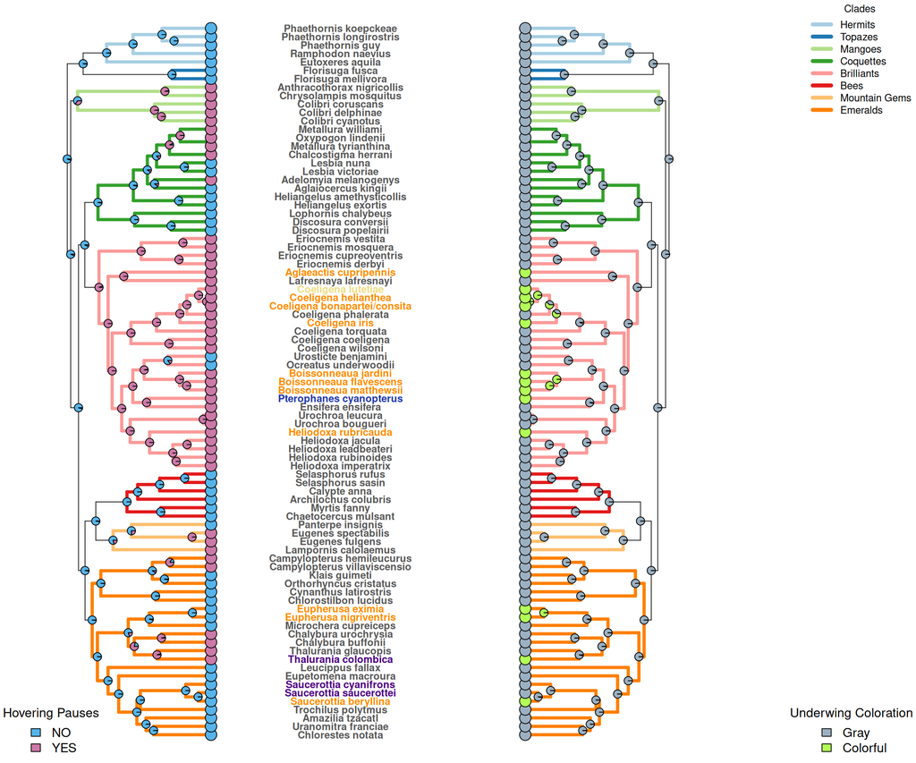

```r
# Colors and Clades
tips_in_order <- tree_bin$tip.label
clades_ordered <- data_bin$clade[match(tips_in_order, data_bin$species)]
unique_clades <- unique(rev(clades_ordered))
cols_clades <- RColorBrewer::brewer.pal(max(length(unique_clades), 3), "Paired")[1:length(unique_clades)]
names(cols_clades) <- unique_clades

edge_cols <- rep("gray10", nrow(tree_bin$edge))
edge_widths <- rep(1, nrow(tree_bin$edge))
for (c in unique_clades) {
    sp_clade <- intersect(data_bin$species[data_bin$clade == c],
                          tree_bin$tip.label)
    if (length(sp_clade) > 0) {
        idx <- which.edge(tree_bin, sp_clade)
        edge_cols[idx] <- cols_clades[c]
        edge_widths[idx] <- 4
    }
}

wing_levels <- unique(trimws(tolower(as.character(data_bin$wing_color))))
cols_wing_map <- setNames(wing_levels, wing_levels)
if ("indigo" %in% names(cols_wing_map)) cols_wing_map["indigo"] <- "#4B0082"
if ("sapphire" %in% names(cols_wing_map)) cols_wing_map["sapphire"] <- "#2138AB"
if ("white" %in% names(cols_wing_map)) cols_wing_map["white"] <- "lightgoldenrod2"
if ("gray" %in% names(cols_wing_map)) cols_wing_map["gray"] <- "gray35"
if ("orange" %in% names(cols_wing_map)) cols_wing_map["orange"] <- "darkorange"

ordered_idx <- match(tree_bin$tip.label, data_bin$species)
ordered_colors <- as.character(data_bin$wing_color[ordered_idx])
cols_wing_sp <- cols_wing_map[trimws(tolower(ordered_colors))]

max_depth <- max(node.depth.edgelength(tree_bin))
xlim_l <- c(-max_depth * 0.35, max_depth * 2.6)
xlim_r <- c(-max_depth * 0.35, max_depth * 2.6)

clean_labels <- gsub("_", " ", tree_bin$tip.label)
clean_labels <- gsub("Coeligena bonapartei", "Coeligena bonapartei/consita", clean_labels)

layout(matrix(c(1,2), 1, 2))
par(oma = c(0, 0, 0, 0), mar = c(0, 0, 2, 0))

states_hover <- setNames(as.character(data_bin$hovering_pauses),
                         data_bin$species)
ace_hover <- ace(states_hover, tree_bin, type = "discrete", model = "ER")

# Usando cols_hover_plt global
plot(tree_bin, cex = 0.8, no.margin = TRUE, label.offset = 0.02,
     direction = "rightwards", show.tip.label = FALSE,
     x.lim = xlim_l, edge.color = edge_cols, edge.width = edge_widths)
nodelabels(pie = ace_hover$lik.anc, piecol = cols_hover_plt, cex = 0.45)
tiplabels(pch = 21, bg = cols_hover_plt[states_hover], cex = 2)
legend("bottomleft", legend = names(cols_hover_plt), fill = cols_hover_plt,
       title = "Hovering Pauses", cex = 1, bty = "n")

pos_center <- max_depth * (2.6 - 1) * 0.5 + (max_depth * 0.1)
tiplabels(text = clean_labels, frame = "none", col = cols_wing_sp,
          font = 2, cex = 0.8, adj = 0.5, offset = pos_center)

if (!exists("ace_color")) {
    states_col <- setNames(as.character(data_bin$color), data_bin$species)
    ace_color <- ace(states_col, tree_bin, type = "discrete", model = "ER")
}

# Usando cols_color_plt global
plot(tree_bin, cex = 0.8, no.margin = TRUE, label.offset = 0.02,
     direction = "leftwards", show.tip.label = FALSE,
     x.lim = xlim_r, edge.color = edge_cols, edge.width = edge_widths)

nodelabels(pie = ace_color$lik.anc, piecol = cols_color_plt, cex = 0.45)
tiplabels(pch = 21, bg = cols_color_plt[data_bin$color], cex = 2)
legend("bottomright", legend = c("Gray", "Colorful"),
       fill = cols_color_plt, title = "Underwing Coloration",
       cex = 1, bty = "n")
legend("topright", legend = names(cols_clades), col = cols_clades,
       lwd = 5, title = "Clades", cex = 0.8, bty = "n", ncol = 1)
```

```r
par(mfrow = c(1,1))
```

### 7.2 Composite Plot: Violins + Forest Plots

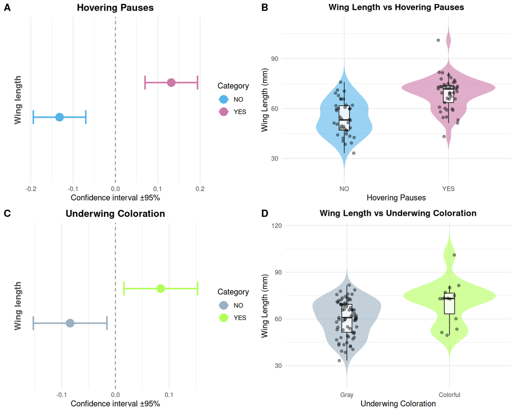

```r
plot_data <- data_bin %>%
    filter(hovering_pauses %in% c("YES", "NO"),
           color %in% c("YES", "NO"),
           !is.na(wing_length)) %>%
    droplevels()

p_violin_hover <- ggplot(plot_data, aes(x = hovering_pauses,
                                        y = wing_length,
                                        fill = hovering_pauses)) +
    geom_violin(trim = FALSE, alpha = 0.6, color = NA) +
    geom_boxplot(width = 0.1, fill = "white",
                 outlier.shape = NA, alpha = 0.8) +
    geom_jitter(width = 0.1, size = 1.5, alpha = 0.4) +
    scale_fill_manual(values = cols_hover_plt) +
    labs(title = "Wing Length vs Hovering Pauses",
         y = "Wing Length (mm)", x = "Hovering Pauses") +
    theme_minimal() + theme(legend.position = "none",
                            plot.title = element_text(face = "bold",
                                                      hjust = 0.5, size = 12))

p_violin_color <- ggplot(plot_data, aes(x = color, y = wing_length,
                                        fill = color)) +
    geom_violin(trim = FALSE, alpha = 0.6, color = NA) +
    geom_boxplot(width = 0.1, fill = "white",
                 outlier.shape = NA, alpha = 0.8) +
    geom_jitter(width = 0.1, size = 1.5, alpha = 0.4) +
    scale_fill_manual(values = cols_color_plt) +
    scale_x_discrete(labels = c("NO" = "Gray",
                                "YES" = "Colorful")) +
    labs(title = "Wing Length vs Underwing Coloration",
         y = "Wing Length (mm)", x = "Underwing Coloration") +
    theme_minimal() +
    theme(legend.position = "none",
          plot.title = element_text(face = "bold", hjust = 0.5, size = 12))

df_conf_hover <- get_forest_data("hovering_pauses", "wing_length",
                                 data_bin, tree_bin, cols_hover_plt)
df_conf_color <- get_forest_data("color", "wing_length", data_bin,
                                 tree_bin, cols_color_plt)

p_conf_hover <- create_forest_plot(df_conf_hover, cols_hover_plt,
                                   "Hovering Pauses")
p_conf_color <- create_forest_plot(df_conf_color, cols_color_plt,
                                   "Underwing Coloration")

plot_grid(p_conf_hover, p_violin_hover, p_conf_color,
          p_violin_color, ncol = 2, align = 'h',
          labels = c("A", "B", "C", "D"))
```

### 7.3 Transition Pauses Analysis

Evolutionary history and morphological distribution for Transition Pauses.

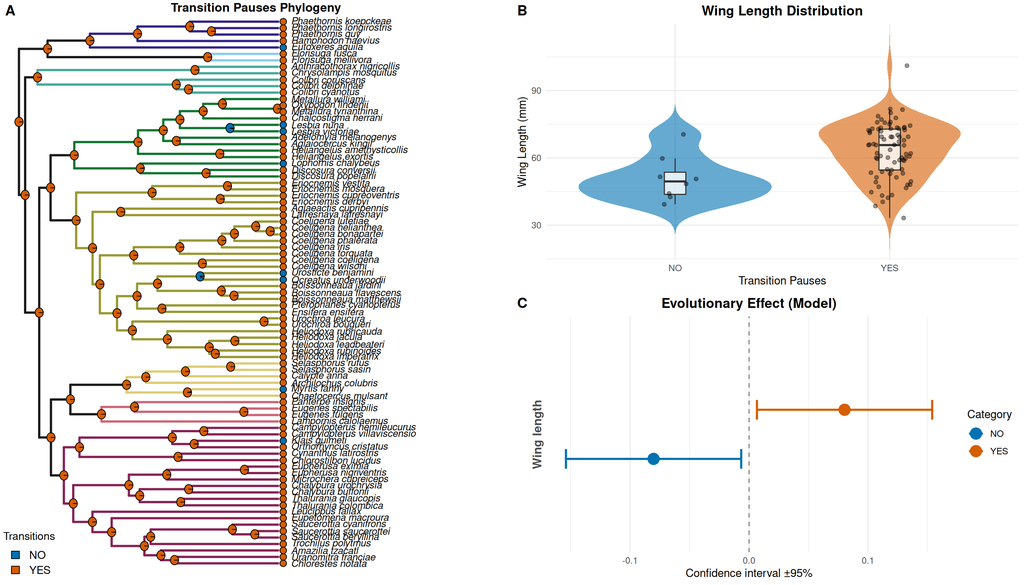

```r
# Colorblind-Friendly Palette for Transition Pauses
cols_trans_plt <- c("NO" = "#0072B2", "YES" = "#D55E00")

# Data Filtering (Patagona is already excluded globally in Section 3)
data_trans_plot <- data_bin %>%
    filter(transition_pauses %in% c("YES", "NO"), !is.na(wing_length)) %>%
    droplevels()

states_trans <- setNames(as.character(data_trans_plot$transition_pauses),
                         data_trans_plot$species)
tree_trans <- keep.tip(tree_bin, names(states_trans))
ace_trans <- ace(states_trans, tree_trans, type = "discrete", model = "ER")

# Inherit Clade Colors for Tree Edges (Matching Tanglegram)
tips_trans <- tree_trans$tip.label
clades_trans <- data_trans_plot$clade[match(tips_trans,
                                            data_trans_plot$species)]
unique_clades_trans <- unique(rev(clades_trans))

safe_clade_palette_ext <- c("#332288",
                            "#88CCEE",
                            "#44AA99",
                            "#117733",
                            "#999933",
                            "#DDCC77",
                            "#CC6677",
                            "#882255",
                            "#AA4499",
                            "#0072B2",
                            "#009E73",
                            "gray50",
                            "gray70")

cols_clades_trans <- setNames(safe_clade_palette_ext[1:length(unique_clades_trans)],
                              unique_clades_trans)

edge_cols_trans <- rep("gray10", nrow(tree_trans$edge))
for (c in unique_clades_trans) {
    sp_clade <- intersect(data_trans_plot$species[data_trans_plot$clade == c],
                          tree_trans$tip.label)
    if (length(sp_clade) > 0) {
        idx <- which.edge(tree_trans, sp_clade)
        edge_cols_trans[idx] <- cols_clades_trans[c]
    }
}

# 4. Tree Plot (Panel A)
p_tree_trans <- as.grob(function() {
    par(mar = c(0, 0, 2, 0))
    plot(tree_trans, cex = 0.8, no.margin = TRUE, label.offset = 0.05,
         direction = "rightwards", show.tip.label = TRUE,
         edge.color = edge_cols_trans, edge.width = 3)
    mtext("Transition Pauses Phylogeny", side = 3, line = -1, font = 2, cex = 1)
    nodelabels(pie = ace_trans$lik.anc, piecol = cols_trans_plt, cex = 0.4)
    tiplabels(pch = 21, bg = cols_trans_plt[states_trans], cex = 1.2, offset = 0.02)
    legend("bottomleft", legend = names(cols_trans_plt), fill = cols_trans_plt,
           title = "Transitions", cex = 0.9, bty = "n")
})

# 5. Violin Plot (Panel B)
p_violin_trans <- ggplot(data_trans_plot, aes(x = transition_pauses,
                                              y = wing_length,
                                              fill = transition_pauses)) +
    geom_violin(trim = FALSE, alpha = 0.6, color = NA) +
    geom_boxplot(width = 0.1, fill = "white", outlier.shape = NA, alpha = 0.8) +
    geom_jitter(width = 0.1, size = 1.5, alpha = 0.4) +
    scale_fill_manual(values = cols_trans_plt) +
    labs(title = "Wing Length Distribution",
         y = "Wing Length (mm)", x = "Transition Pauses") +
    theme_minimal() + theme(legend.position = "none",
                            plot.title = element_text(face = "bold", hjust = 0.5))

# 6. Forest Plot (Panel C)
df_conf_trans <- get_forest_data("transition_pauses", "wing_length",
                                 data_trans_plot, tree_trans, cols_trans_plt)
p_forest_trans <- create_forest_plot(df_conf_trans, cols_trans_plt,
                                     "Evolutionary Effect (Model)")

# 7. Assemble Composite Plot
col_right <- plot_grid(p_violin_trans, p_forest_trans, ncol = 1,
                       labels = c("B", "C"))
final_trans_plot <- plot_grid(p_tree_trans, col_right, ncol = 2,
                              labels = c("A", ""), rel_widths = c(1, 1))

print(final_trans_plot)
```

### 7.4 Clade-Level Morphology

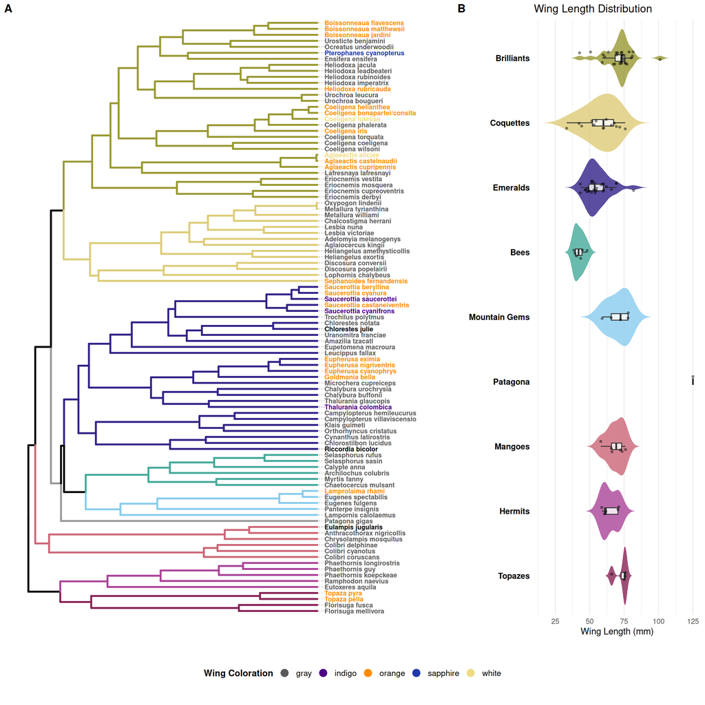

```r
df_phylo_morpho <- data_clean %>%
    filter(species != "Sternoclyta_cyanopectus", !is.na(wing_length)) %>%
    droplevels()

tree_phylo_morpho <- keep.tip(tree_mod, intersect(tree_mod$tip.label,
                                                  df_phylo_morpho$species))
df_phylo_morpho <- df_phylo_morpho[match(tree_phylo_morpho$tip.label,
                                         df_phylo_morpho$species), ]

df_phylo_morpho$clean_label <- gsub("_", " ", df_phylo_morpho$species)
df_phylo_morpho$clean_label <- gsub("Coeligena bonapartei",
                                    "Coeligena bonapartei/consita",
                                    df_phylo_morpho$clean_label)

df_phylo_morpho$tip_color_hex <- cols_wing_map[trimws(
    tolower(as.character(df_phylo_morpho$wing_color)))]
na_idx <- which(is.na(df_phylo_morpho$tip_color_hex))
if(length(na_idx) > 0) df_phylo_morpho$tip_color_hex[na_idx] <- "black"
white_idx <- which(df_phylo_morpho$tip_color_hex %in% c("white",
                                                        "#FFFFFF",
                                                        "#ffffff"))
if(length(white_idx) > 0) df_phylo_morpho$tip_color_hex[white_idx] <- "gray40"

legend_data <- data.frame(Color_Name = names(cols_wing_map),
                          Color_Hex = as.character(cols_wing_map))
legend_data$Color_Name[legend_data$Color_Hex == "beige"] <- "white"
p_legend <- ggplot(legend_data, aes(x=1, y=1, color=Color_Name)) +
    geom_point(size=4) +
    scale_color_manual(name = "Wing Coloration", values = cols_wing_map) +
    theme_void() +
    theme(legend.position = "bottom", legend.title = element_text(face="bold"), legend.text = element_text(size=10))
wing_legend <- get_legend(p_legend)

# Ampliar la paleta para cubrir todos los clados (incluyendo a Patagona gigas)
clades_for_plot <- unique(df_phylo_morpho$clade)
safe_clade_palette_ext <- c("#332288",
                            "#88CCEE",
                            "#44AA99",
                            "#117733",
                            "#999933",
                            "#DDCC77",
                            "#CC6677",
                            "#882255",
                            "#AA4499",
                            "#0072B2",
                            "#009E73",
                            "gray50",
                            "gray70")
cols_clades_plot <- setNames(safe_clade_palette_ext[1:length(clades_for_plot)],
                             clades_for_plot)
# Si Patagona está sola en su clado, forzamos que sea gris para que no resalte
if("Patagona" %in% names(cols_clades_plot)) cols_clades_plot["Patagona"] <- "gray60"

clade_list <- split(df_phylo_morpho$species, df_phylo_morpho$clade)
tree_grouped_full <- groupOTU(tree_phylo_morpho, clade_list)

p_tree_final <- ggtree(tree_grouped_full, aes(color = group),
                       layout = "rectangular", size = 1.1) %<+% df_phylo_morpho +
    scale_color_manual(values = c("0" = "black", cols_clades_plot)) +
    geom_tiplab(aes(label = clean_label, color = I(tip_color_hex)),
                size = 2.8, fontface = "bold", align = TRUE,
                linesize = 0.3, offset = 0.02) +
    theme_tree() +
    theme(legend.position = "none", plot.margin = margin(10, 0, 10, 10)) +
    xlim(0, max(node.depth.edgelength(tree_phylo_morpho)) * 1.4)

tips_order_final <- get_taxa_name(p_tree_final)
ordered_df <- df_phylo_morpho[match(tips_order_final, df_phylo_morpho$species), ]
clade_appearance <- unique(ordered_df$clade)
df_phylo_morpho$clade_ordered <- factor(df_phylo_morpho$clade,
                                        levels = rev(clade_appearance))

p_violin_final <- ggplot(df_phylo_morpho, aes(x = clade_ordered,
                                              y = wing_length,
                                              fill = clade_ordered)) +
    geom_violin(trim = FALSE, scale = "width", alpha = 0.8, color = NA) +
    geom_boxplot(width = 0.1, fill = "white",
                 outlier.shape = NA, alpha = 0.8) +
    geom_jitter(width = 0.1, size = 1, alpha = 0.4, color = "black") +
    scale_fill_manual(values = cols_clades_plot) +
    coord_flip() +
    labs(title = "Wing Length Distribution", x = "", y = "Wing Length (mm)") +
    theme_minimal() +
    theme(legend.position = "none",
          axis.text.y = element_text(size = 10, face = "bold", color = "black"),
          panel.grid.major.y = element_blank())

main_plot <- plot_grid(p_tree_final, p_violin_final,
                       ncol = 2, align = "h", axis = "bt",
                       rel_widths = c(1.8, 1), labels = c("A", "B"))
plot_grid(main_plot, wing_legend, ncol = 1, rel_heights = c(1, 0.1))
```

## 8. Comparative Summary Table

Summary of evolutionary statistics and PGLS models.

```r
# Dynamically calculate metrics for the 4 morphometric models
calculate_dynamic_metrics <- function(col_name, df_full, phy_tree) {
    # 3 variables de evaluación
    morpho_vars <- c("wing_length", "body_mass", "wing_loading")
    results <- c()

    data_base_trait <- df_full %>%
        dplyr::select(species, all_of(col_name)) %>%
        rename(trait_cat = all_of(col_name)) %>%
        filter(trait_cat %in% c("YES", "NO")) %>%
        drop_na() %>%
        droplevels()

    sp_trait <- intersect(data_base_trait$species, phy_tree$tip.label)
    tree_trait <- keep.tip(phy_tree, sp_trait)
    data_base_trait <- data_base_trait[match(sp_trait, data_base_trait$species), ]

    states_vec <- setNames(as.character(data_base_trait$trait_cat),
                           data_base_trait$species)
    fit_mk <- fitMk(tree_trait, states_vec, model = "ER")

    data_base_trait$trait_bin <- ifelse(data_base_trait$trait_cat == "YES", 1, 0)
    comp_data_d <- comparative.data(tree_trait, data.frame(data_base_trait),
                                    names.col = "species")
    d_stat <- phylo.d(comp_data_d, binvar = trait_bin, permut = 200)

    results <- c(
        "N (Species)"      = nrow(data_base_trait),
        "ACE Rate (q)"     = sprintf("%.4f", fit_mk$rates),
        "Phylo Signal (D)" = sprintf("%.3f", d_stat$DEstimate),
        "D P-value"        = sprintf("%.4f", d_stat$Pval1)
    )

    # Procesar iterativamente asegurando compatibilidad si la columna existe en dataset
    for (var in morpho_vars) {
        if (!var %in% colnames(df_full)) {
           results <- c(results, "PGLS Lambda" = NA, "PGLS F-stat" = NA,
                        "PGLS P-value" = NA, "PGLS AIC" = NA)
           next
        }

        data_var <- df_full %>%
            dplyr::select(species, all_of(col_name), all_of(var)) %>%
            rename(trait_cat = all_of(col_name)) %>%
            filter(trait_cat %in% c("YES", "NO")) %>% drop_na() %>% droplevels()

        sp_var <- intersect(data_var$species, phy_tree$tip.label)
        tree_var <- keep.tip(phy_tree, sp_var)
        data_var <- data_var[match(sp_var, data_var$species), ]

        comp_data_pgls <- comparative.data(tree_var, data.frame(data_var),
                                           names.col = "species", vcv = TRUE)
        form_pgls <- as.formula(paste(var, "~ trait_cat"))
        mod_pgls <- pgls(form_pgls, data = comp_data_pgls, lambda = "ML")
        sum_pgls <- summary(mod_pgls)

        f_stat <- sum_pgls$fstatistic[1]
        p_val <- pf(f_stat, sum_pgls$fstatistic[2], sum_pgls$fstatistic[3],
                    lower.tail = FALSE)

        results <- c(results,
            "PGLS Lambda" = sprintf("%.3f", sum_pgls$param["lambda"]),
            "PGLS F-stat" = sprintf("%.2f", f_stat),
            "PGLS P-value" = sprintf("%.5f", p_val),
            "PGLS AIC"    = sprintf("%.1f", AIC(mod_pgls))
        )
    }
    return(results)
}

res_hover <- calculate_dynamic_metrics("hovering_pauses", data_bin, tree_bin)
res_trans <- calculate_dynamic_metrics("transition_pauses", data_bin, tree_bin)
res_color <- calculate_dynamic_metrics("color", data_bin, tree_bin)

df_base <- data.frame(
    Metric = names(res_hover),
    Hovering = res_hover,
    Transitions = res_trans,
    Coloration = res_color,
    stringsAsFactors = FALSE
)
rownames(df_base) <- NULL

df_formatted <- df_base
# Dynamic indices for p-values with 3 morphometrics (rows 7, 11, 15)
for (r in seq(7, 15, by=4)) {
    for(c in 2:4) {
        val_num <- as.numeric(df_formatted[r, c])
        if(!is.na(val_num) && val_num < 0.05) {
            # Use HTML tags instead of LaTeX for proper HTML rendering
            df_formatted[r, c] <- paste0("<span style='color:red; font-weight:bold;'>",
                                         df_formatted[r, c], "</span>")
        }
    }
}

tabla_final <- kbl(df_formatted, escape = FALSE, align = "lccc",
    caption = "Comparative Summary of Evolutionary Statistics and PGLS Models") %>%
    kable_classic(full_width = F, html_font = "Cambria") %>%
    pack_rows("1. Evolutionary Signal (Categorical Trait)", 1, 4, bold = TRUE,
              label_row_css = "background-color:#ecf0f1;") %>%
    pack_rows("2. Model: Wing Length ~ Trait", 5, 8, bold = TRUE,
              label_row_css = "background-color:#d1f2eb;") %>%
    pack_rows("3. Model: Body Mass ~ Trait", 9, 12, bold = TRUE,
              label_row_css = "background-color:#d6eaf8;") %>%
    pack_rows("4. Model: Wing Loading ~ Trait", 13, 16, bold = TRUE,
              label_row_css = "background-color:#fadbd8;")

tabla_final
```

Comparative Summary of Evolutionary Statistics and PGLS Models

| Metric | Hovering | Transitions | Coloration |
| --- | --- | --- | --- |
| **1. Evolutionary Signal (Categorical Trait)** |  |  |  |
| N (Species) | 85 | 85 | 85 |
| ACE Rate (q) | 0.3267 | 0.1709 | 0.2661 |
| Phylo Signal (D) | -0.939 | -0.002 | -0.165 |
| D P-value | 0.0000 | 0.0050 | 0.0000 |
| **2. Model: Wing Length ~ Trait** |  |  |  |
| PGLS Lambda | 0.776 | 0.826 | 0.833 |
| PGLS F-stat | 20.96 | 9.42 | 5.23 |
| PGLS P-value | 0.00002 | 0.00290 | 0.02471 |
| PGLS AIC | 616.6 | 626.0 | 629.9 |
| **3. Model: Body Mass ~ Trait** |  |  |  |
| PGLS Lambda | 0.821 | 0.853 | 0.861 |
| PGLS F-stat | 17.87 | 7.18 | 0.30 |
| PGLS P-value | 0.00006 | 0.00889 | 0.58558 |
| PGLS AIC | 337.0 | 346.3 | 353.1 |
| **4. Model: Wing Loading ~ Trait** |  |  |  |
| PGLS Lambda | 0.000 | 0.000 | 0.000 |
| PGLS F-stat | 0.51 | 0.07 | 0.23 |
| PGLS P-value | 0.47697 | 0.78611 | 0.63392 |
| PGLS AIC | 326.1 | 326.6 | 326.4 |